# Perform WGCNA

```r
#setwd('/afs/inf.ed.ac.uk/user/s17/s1725186/Documents/PhD-Models/FirstPUModel/RMarkdowns')

library(tidyverse) ; library(reshape2) ; library(glue) ; library(dendextend)
library(RColorBrewer) ; require(gridExtra) ; library(GGally)
suppressMessages(library(WGCNA))
library(ClusterR)
library(expss)
```

Load preprocessed dataset (preprocessing code in 01_data_preprocessing.Rmd)

```r
# Gandal dataset
load('./../Data/preprocessed_data.RData')
datExpr = datExpr %>% data.frame
rownames(datExpr) = datGenes$ensembl_gene_id
datMeta = datMeta %>% mutate(ID = title)

# GO Neuronal annotations: regex 'neuron' in GO functional annotations and label the genes that make a match as neuronal
GO_annotations = read.csv('./../Data/genes_GO_annotations.csv')
GO_neuronal = GO_annotations %>% filter(grepl('neuron', go_term)) %>%
              mutate('ID'=as.character(ensembl_gene_id)) %>%
              dplyr::select(-ensembl_gene_id) %>% distinct(ID) %>%
              mutate('Neuronal'=1)


# SFARI Genes
SFARI_genes = read_csv('./../../../SFARI/Data/SFARI_genes_01-03-2020_w_ensembl_IDs.csv')
SFARI_genes = SFARI_genes[!duplicated(SFARI_genes$ID) & !is.na(SFARI_genes$ID),]


# Get colors from the ggplot palette
gg_colour_hue = function(n) {
  hues = seq(15, 375, length = n+1)
  pal = hcl(h = hues, l = 65, c = 100)[1:n]
}

rm(GO_annotations)
```

# Perform Clustering

Pipeline summary:

- Using biweight correlation as correlation metric
- Using signed hybrid function to create the adjacency matrix
- Elevating the adjacency matrix to the best power to obtain a scale-free topology
- Using a Topological Overlap Matrix (TOM) as distance matrix
- Performing hierarchical clustering (using average linkage hclust(method=‘average’))
- Extracting clusters using the Dynamic Tree brach cutting algorithm from [Dynamic Tree Cut: in-depth description, tests and applications](https://horvath.genetics.ucla.edu/html/CoexpressionNetwork/BranchCutting/Supplement.pdf)
- Merging similar clusters using Module Eigengenes
- Saving results with different cluster merges so we can decide which to use later

### Define a gene co-expression similarity

Using Biweight midcorrelation because it’s more robust to outliers than regular correlation or Mutual Information score

Notes on each method:

- Using the unsigned adjacency we lose the direction of the correlation, but at least we maintain the magnitude of the correlation of all the genes
- Using the signed adjacency, the strongest negative correlations (-1) get mapped to 0 (no correlation) and the zero correlated genes get mapped to the average correlation (0.5), which I don’t think makes much sense
- Using the signed hybrid adjacency, we lose all the negative correlations but we mantain the magnitude of the positive ones. This seems to be the best option since genes with negative correlations usually don’t share the same biological pathways, so losing this information is not as important as maintaining the correct information for the genes with the positive correlation (and combining together these two types of correlation as the unsigned approach does seems to mix different behaviours together)

**Note:** According to [this post](https://peterlangfelder.com/2018/11/25/__trashed/) in practice there’s not a big difference between signed and signed hybrid adjacencies because you end up elevating the values to a certain power, which in both cases moves the negative correlations to nearly zero.

### Define a family of adjacency functions

- Sigmoid function: $a(i,j)=sigmoid(s_{ij}, \alpha, \tau_0) \equiv \frac{1}{1+e^{-\alpha(s_{ij}-\tau_0)}}$
- Power adjacency function: $a(i,j)=power(s_{ij}, \beta) \equiv |S_{ij}|^\beta$

Chose power adjacency function over the sigmoid function because it has only one parameter to adjust and both methods are supposed to lead to very similar results if the parameters are chosen with the scale-free topology criterion.

### Choosing a parameter value

Following the **scale-free topology criterion** because metabolic networks have been found to display approximate scale free topology

1. Only consider those parameter values that lead to a network satisfying scale-free topology at least approximately, e.g. signed $R^2 > 0.80$

**Note:** Including non-integer powers in the parameters. Integer powers are usually used for this but there’s no reason why you can’t use a non-integer power and you can get a lower power vector that is above the 0.8 threshold so you don’t affect the data that much

```r
allowWGCNAThreads()
```

```
## Allowing multi-threading with up to 8 threads.
```

```r
best_power = datExpr %>% t %>% pickSoftThreshold(powerVector = c(1,2,3,seq(4,5,0.1)), RsquaredCut=0.8)
```

```
##    Power SFT.R.sq slope truncated.R.sq mean.k. median.k. max.k.
## 1    1.0   0.0398 -2.64          0.984  2230.0    2220.0 3000.0
## 2    2.0   0.2580 -3.52          0.984   502.0     495.0  890.0
## 3    3.0   0.4890 -3.46          0.968   142.0     138.0  330.0
## 4    4.0   0.7150 -3.55          0.959    47.1      44.5  144.0
## 5    4.1   0.7370 -3.60          0.963    42.5      40.0  135.0
## 6    4.2   0.7590 -3.66          0.966    38.3      36.0  126.0
## 7    4.3   0.7780 -3.68          0.967    34.7      32.4  118.0
## 8    4.4   0.7970 -3.70          0.969    31.3      29.2  111.0
## 9    4.5   0.8140 -3.75          0.974    28.4      26.4  105.0
## 10   4.6   0.8290 -3.77          0.974    25.7      23.8   98.6
## 11   4.7   0.8410 -3.81          0.977    23.3      21.5   93.0
## 12   4.8   0.8490 -3.85          0.978    21.2      19.5   87.8
## 13   4.9   0.8610 -3.84          0.980    19.3      17.6   83.0
## 14   5.0   0.8720 -3.83          0.980    17.5      16.0   78.6
```

Best power for scale free topology: 4.5

```r
S_sft = datExpr %>% t %>% adjacency(type='signed hybrid', power=best_power$powerEstimate, corFnc='bicor')
```

## Defining a measure of node dissimilarity

Using topological overlap dissimilarity measure because it has been found to result in biologically meaningful modules

```r
TOM = S_sft %>% TOMsimilarity
```

```
## ..connectivity..
## ..matrix multiplication (system BLAS)..
## ..normalization..
## ..done.
```

```r
rownames(TOM) = rownames(S_sft)
colnames(TOM) = colnames(S_sft)

#library(igraph)
#g = graph_from_adjacency_matrix(TOM, weighted=TRUE, mode='undirected')
#edges = as_edgelist(g)
#e = cbind(edges, E(g)$weight)

dissTOM = 1-TOM

rm(S_sft, TOM)
```

## Identifying gene modules

Using hierarchical clustering using average linkage on the TOM-based dissimilarity matrix

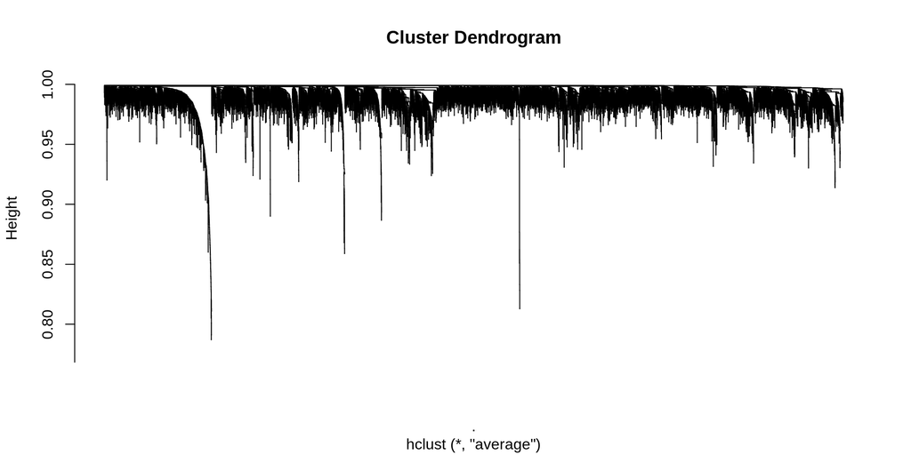

```r
dend = dissTOM %>% as.dist %>% hclust(method='average')
plot(dend, hang=0, labels=FALSE)
```

Instead of using a fixed height to cut the dendrogram into clusters, using a dynamic branch cutting approach taken from [Dynamic Tree Cut: in-depth description, tests and applications](https://horvath.genetics.ucla.edu/html/CoexpressionNetwork/BranchCutting/Supplement.pdf)

There are two algorithms that do this:

**Dynamic Tree Cut:** top-down algorithm relying only on the dendrogram and respecting the order of the clustered objects on it. This method is less sensitive to parameter choice but also less flexible and it performed better in our previous experiments **but** when using it on this dataset it left most genes without a cluster, so tried doing it also with the Dynamic Hybrid algorithm

**Dynamic Hybrid Cut:** builds the clusters from bottom up. In addition to information from the dendrogram, it utilizes dissimilarity information among the objects. Seems to me that relies on too many heuristics and has too many parameters to tune. Ran it with the default settings

### Dynamic Tree Cut Algorithm

This algorithm leaves a lot of genes without a cluster, specially genes close to the root of the dendrogram which is uncertain how to assign. I’ll save the results for this algorithm for completeness, but will use the output from Dynamic Hybrid Cut for the rest of the analysis

```r
modules = cutreeDynamic(dend, method = 'tree', minClusterSize = 10)
```

12883 genes (84%) are left without a cluster

```r
table(modules)
```

```
## modules
##     0     1     2     3     4     5     6     7     8     9    10    11    12
## 12883   271   160    91    88    86    65    61    58    48    43    39    38
##    13    14    15    16    17    18    19    20    21    22    23    24    25
##    38    36    33    32    30    29    29    28    28    28    27    27    26
##    26    27    28    29    30    31    32    33    34    35    36    37    38
##    25    25    25    25    24    24    23    23    23    22    21    20    19
##    39    40    41    42    43    44    45    46    47    48    49    50    51
##    19    18    18    17    17    17    16    16    16    15    15    15    15
##    52    53    54    55    56    57    58    59    60    61    62    63    64
##    15    14    14    14    14    14    14    14    14    14    14    14    13
##    65    66    67    68    69    70    71    72    73    74    75    76    77
##    13    13    13    13    13    13    13    13    12    12    12    12    12
##    78    79    80    81    82    83    84    85    86    87    88    89    90
##    12    12    12    12    12    12    12    12    11    11    11    11    11
##    91    92    93    94    95    96
##    10    10    10    10    10    10
```

```r
# Note: The modules are ordered as in the rows in datExpr
```

#### Merging similar modules

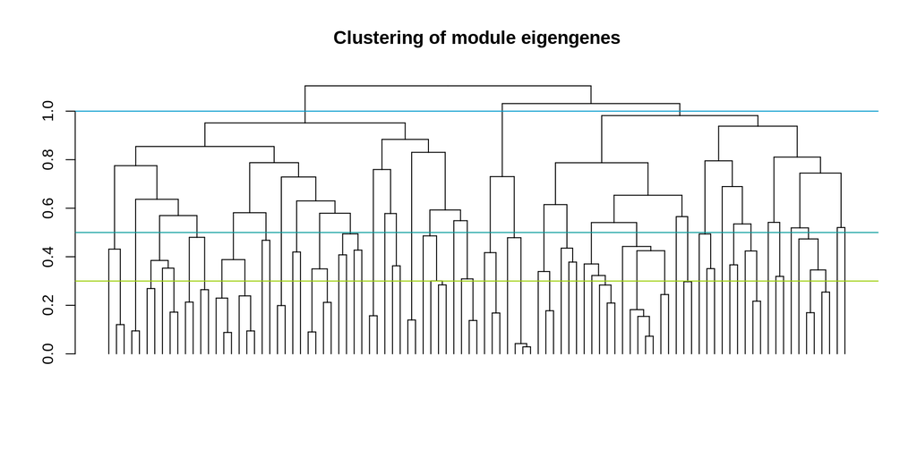

```r
# Calculate eigengenes
MEList = datExpr %>% t %>% moduleEigengenes(colors = modules)
MEs = MEList$eigengenes

# Calculate dissimilarity of module eigengenes
MEDiss = 1-cor(MEs)

# Cluster module eigengenes
METree = hclust(as.dist(MEDiss), method = 'average')

METree %>% as.dendrogram %>% plot(main = 'Clustering of module eigengenes', leaflab = 'none')
abline(h=1, col='#0099cc')
abline(h=0.5, col='#009999')
abline(h=0.3, col='#99cc00')
```

```r
merge_top = datExpr %>% t %>% mergeCloseModules(modules, cutHeight = 1)
```

```
##  mergeCloseModules: Merging modules whose distance is less than 1
##    Calculating new MEs...
```

```r
merge_similar = datExpr %>% t %>% mergeCloseModules(modules, cutHeight = 0.5)
```

```
##  mergeCloseModules: Merging modules whose distance is less than 0.5
##    Calculating new MEs...
```

```r
merge_most_similar = datExpr %>% t %>% mergeCloseModules(modules, cutHeight = 0.3)
```

```
##  mergeCloseModules: Merging modules whose distance is less than 0.3
##    Calculating new MEs...
```

```r
rm(MEList, MEs, MEDiss, METree)
```

#### Module assignment

Almost all of the genes except the ones farthest away from the root remain unclassified

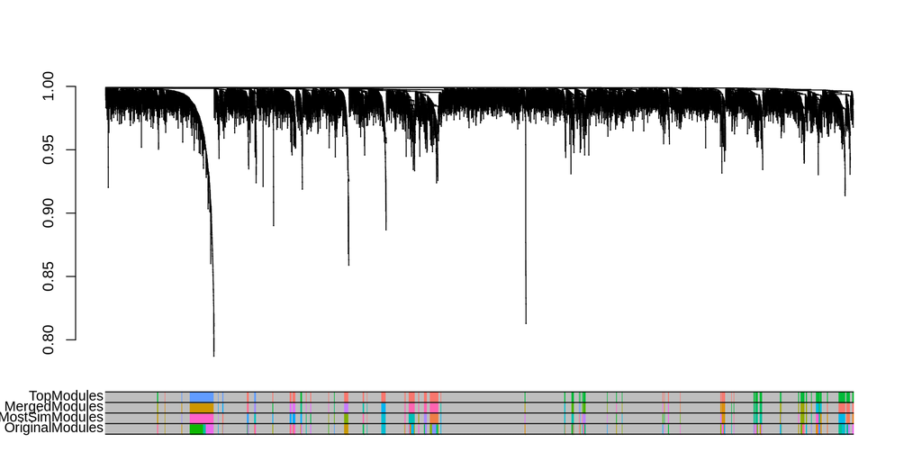

```r
get_mod_colours = function(mods){

  n = length(unique(mods))-1
  set.seed(123) ; rand_order = sample(1:n)
  mod_colors = c('gray',gg_colour_hue(n)[rand_order])
  names(mod_colors) = mods %>% table %>% names

  return(mod_colors)
}

module_colors = get_mod_colours(modules)
merged_sim_module_colors = get_mod_colours(merge_most_similar$colors)
merged_module_colors = get_mod_colours(merge_similar$colors)
top_module_colors = get_mod_colours(merge_top$colors)

dend_colors = data.frame('ID' = rownames(datExpr),
                         'OriginalModules' = module_colors[as.character(modules)],
                         'MostSimModules' = merged_sim_module_colors[as.character(merge_most_similar$colors)],
                         'MergedModules' = merged_module_colors[as.character(merge_similar$colors)],
                         'TopModules' = top_module_colors[as.character(merge_top$colors)])

dend %>% as.dendrogram(hang=0) %>% plot(ylim=c(min(dend$height),1), leaflab='none')
colored_bars(colors=dend_colors[dend$order,-1])
```

```r
rm(module_colors, merged_sim_module_colors, merged_module_colors, top_module_colors)
```

```r
modules_dynamic_tree = dend_colors

rm(dend_colors)
```

### Dynamic Hybrid Cut Algorithm

```r
modules = cutreeDynamic(dend, minClusterSize = 10, distM = dissTOM)
```

```
##  ..cutHeight not given, setting it to 0.999  ===>  99% of the (truncated) height range in dendro.
##  ..done.
```

2188 genes (14.22%) are left without a cluster

```r
table(modules)
```

```
## modules
##    0    1    2    3    4    5    6    7    8    9   10   11   12   13   14   15
## 2188  926  273  225  223  216  205  203  198  197  190  188  173  166  165  154
##   16   17   18   19   20   21   22   23   24   25   26   27   28   29   30   31
##  151  150  147  143  140  139  126  126  120  117  115  114  112  111  108  105
##   32   33   34   35   36   37   38   39   40   41   42   43   44   45   46   47
##  103  102   99   99   97   95   92   91   91   91   90   89   89   88   88   88
##   48   49   50   51   52   53   54   55   56   57   58   59   60   61   62   63
##   86   85   84   83   82   77   77   76   75   74   73   73   73   72   72   71
##   64   65   66   67   68   69   70   71   72   73   74   75   76   77   78   79
##   70   70   69   69   69   68   67   67   66   65   64   63   63   62   62   61
##   80   81   82   83   84   85   86   87   88   89   90   91   92   93   94   95
##   61   61   61   61   60   60   60   60   59   59   58   58   57   56   55   55
##   96   97   98   99  100  101  102  103  104  105  106  107  108  109  110  111
##   55   54   54   54   53   53   52   51   49   49   49   49   49   48   47   44
##  112  113  114  115  116  117  118  119  120  121  122  123  124  125  126  127
##   44   44   43   42   42   41   40   40   40   39   39   39   39   38   37   37
##  128  129  130  131  132  133  134  135  136  137  138  139  140  141  142  143
##   35   35   35   35   34   33   33   33   32   32   32   32   32   31   31   31
##  144  145  146  147  148  149  150  151  152  153  154  155  156  157  158  159
##   30   30   29   29   28   28   28   27   26   26   26   26   26   25   25   24
##  160  161  162  163  164  165  166  167  168  169  170  171  172  173  174  175
##   24   23   23   22   22   20   19   18   18   18   16   15   15   14   14   14
##  176  177  178  179
##   13   13   13   10
```

#### Merging similar modules

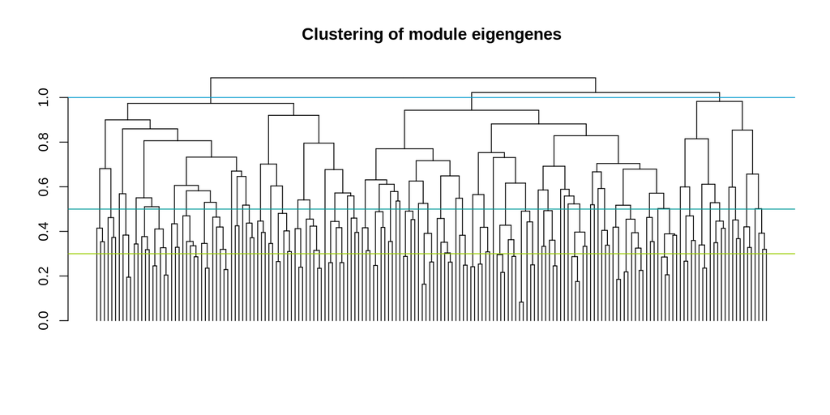

```r
# Calculate eigengenes
MEList = datExpr %>% t %>% moduleEigengenes(colors = modules)
MEs = MEList$eigengenes

# Calculate dissimilarity of module eigengenes
MEDiss = 1-cor(MEs)

# Cluster module eigengenes
METree = hclust(as.dist(MEDiss), method = 'average')

METree %>% as.dendrogram %>% plot(main = 'Clustering of module eigengenes', leaflab = 'none')
abline(h=1, col='#0099cc')
abline(h=0.5, col='#009999')
abline(h=0.3, col='#99cc00')
```

```r
merge_top = datExpr %>% t %>% mergeCloseModules(modules, cutHeight = 1)
```

```
##  mergeCloseModules: Merging modules whose distance is less than 1
##    Calculating new MEs...
```

```r
merge_similar = datExpr %>% t %>% mergeCloseModules(modules, cutHeight = 0.5)
```

```
##  mergeCloseModules: Merging modules whose distance is less than 0.5
##    Calculating new MEs...
```

```r
merge_most_similar = datExpr %>% t %>% mergeCloseModules(modules, cutHeight = 0.3)
```

```
##  mergeCloseModules: Merging modules whose distance is less than 0.3
##    Calculating new MEs...
```

```r
rm(MEList, MEs, MEDiss, METree)
```

#### Module assignment

Classification is noisy with respect to the dendrogram, but that isn’t necessarily a bad thing, as Peter Langfelder explains in [this blog post](https://peterlangfelder.com/2018/12/30/why-wgcna-modules-dont-always-agree-with-the-dendrogram/) from [Insights from a Million Correlations](https://peterlangfelder.com/articles/)

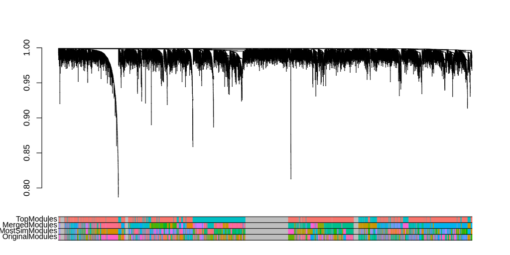

```r
module_colors = get_mod_colours(modules)
merged_sim_module_colors = get_mod_colours(merge_most_similar$colors)
merged_module_colors = get_mod_colours(merge_similar$colors)
top_module_colors = get_mod_colours(merge_top$colors)

dend_colors = data.frame('ID' = rownames(datExpr),
                         'OriginalModules' = module_colors[as.character(modules)],
                         'MostSimModules' = merged_sim_module_colors[as.character(merge_most_similar$colors)],
                         'MergedModules' = merged_module_colors[as.character(merge_similar$colors)],
                         'TopModules' = top_module_colors[as.character(merge_top$colors)])

dend %>% as.dendrogram(hang=0) %>% plot(ylim=c(min(dend$height),1), leaflab='none')
colored_bars(colors=dend_colors[dend$order,-1])
```

```r
rm(module_colors, merged_module_colors, top_module_colors)
```

```r
modules_dynamic_hybrid = dend_colors

rm(dend_colors)
```

Save clusterings file

```r
colnames(modules_dynamic_tree) = c('ID','DynamicTree', 'DynamicTreeMergedSmall', 'DynamicTreeMerged', 'DynamicTreeTop')
colnames(modules_dynamic_hybrid) = c('ID','DynamicHybrid', 'DynamicHybridMergedSmall', 'DynamicHybridMerged', 'DynamicHybridTop')

modules = modules_dynamic_tree %>% left_join(modules_dynamic_hybrid, by='ID')

write.csv(modules, file='./../Data/clusters.csv', row.names=FALSE)
```